# Main Report

Team M

September 26, 2017

# Introduction

Marriage is such a big topic in human life and always a very strong predictor of people’s life satisfaction and happiness level. However, not all marriages are eternal happy endings and a lot of them nowadays end in divorce. If we can understand the factors that influence the quality of marriage, we may be able to discover more preventive measures to help more people maintain a lifelong happy marriage.

To answer this question, our group examined the 2011 UK Census data and limited our scope to the marital status of a sample of British people.

To clarify, we define divorce rate here as (total number of divorce or separated)/(total number of marriage). Thus, we exclude all people who have not yet married, and the people who end their marriages out of other reasons such as the other partner’s death.

## Description

The dataset we examined is the 5% sample data of the 2011 UK Census. It contains 2,848,155 observations and 121 variables. Each observation represents a UK citizen Since the dataset is very large and there are too many variables, we decided to exclusively focus on the relationship between marital status (marstat) and other variables. In brief, we would like to examine the factors that may influence people’s marriage and lead to higher divorce rate. Therefore, we selected a total of 17 variables that may be highly correlated with marital status.

# Methods

```r
library(dplyr)
library(ggplot2)
library(stargazer)
library(readr)
```

# Descriptive Statistics and Correlation Tests

## Social and Economic Status & Marriage

## Religion and Culture & Marriage

## Region/Geography & Marriage

## Health & Marriage

```
##
##  Pearson's Chi-squared test
##
## data:  mine$binary_marstat and mine$disability
## X-squared = 5428.6, df = 2, p-value < 2.2e-16
```

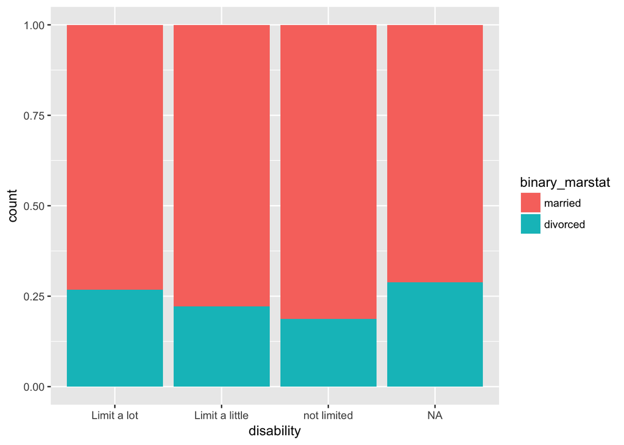

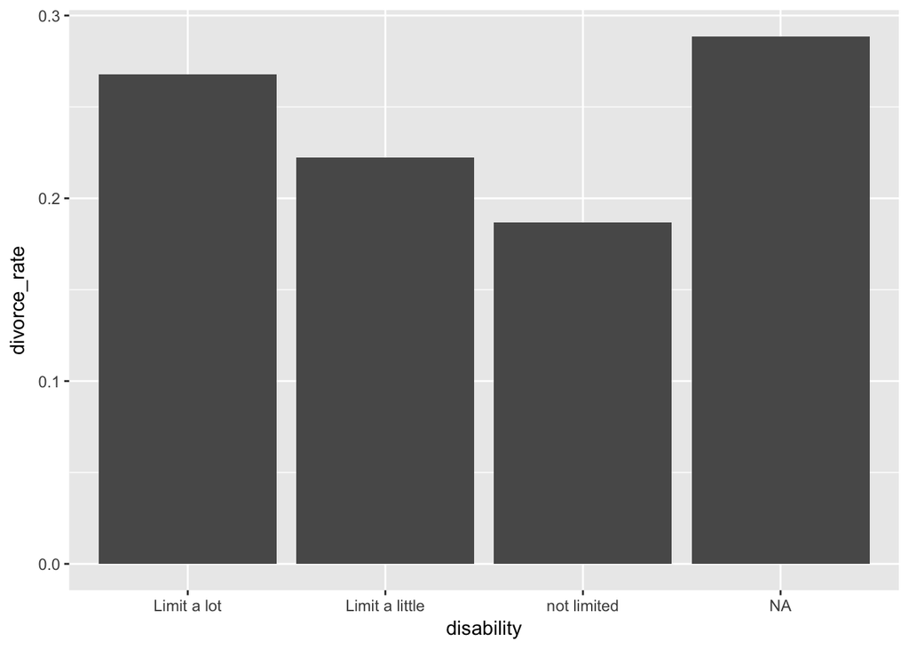

The graph shows that the less severe the long-term health problem, the less the divorced rate.

# Logistic Regression

# Hypothesis Testing and Prediction Model (Helene’s)

# Conclusion

# Apendix